# Statistical graphs (advanced)

[Dr. Peng Zhao](https://connect.xjtlu.edu.cn/user/pengzhao) (✉ peng.zhao@xjtlu.edu.cn)

Department of Health and Environmental Sciences  
Xi’an Jiaotong-Liverpool University

# 1 Learning objectives

- Criticize statistical graphs in public media and academic publications.
- Display maths expressions in graphs with R functions.
- Use proper layouts and cross-references for graphs in academic writing.

# 2 Bad graphs

## 2.1 Simple examples

What redundant information can you remove?

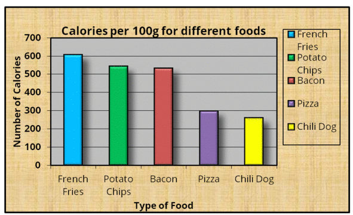

## 2.2 Cases in academic journals

1. [Roeder (1994)](https://www.jstor.org/stable/2246327) DNA fingerprinting: A review of the controversy (with discussion). Statistical Science 9:222-278, Figure 4
2. [Wittke-Thompson et al. (2005)](https://www.ncbi.nlm.nih.gov/pmc/articles/PMC1196455/) Rational inferences about departures from Hardy-Weinberg equilibrium. American Journal of Human Genetics 76:967-986, Figure 1
3. [Kim et al. (2012)](https://www.ncbi.nlm.nih.gov/pmc/articles/PMC3349033/) Higher levels of serum triglyceride and dietary carbohydrate intake are associated with smaller LDL particle size in healthy Korean women. Nutrition Research and Practice 6:120-125, Figure 1
4. [Cotter et al. (2004)](https://www.sciencedirect.com/science/article/abs/pii/S0895435604001398?via%3Dihub) Hematocrit was not validated as a surrogate endpoint for survival amoung epoetin-treated hemodialysis patients. Journal of Clinical Epidemiology 57:1086-1095, Figure 2

# 3 Graphs in writing

## 3.1 Maths

```r
plot(CO2$conc, CO2$uptake, pch = 16, las = 1,
     xlab = 'CO2 concentration', ylab = 'CO2 uptake')
help("CO2")
plot(CO2$conc, CO2$uptake, pch = 16, las = 1,
     xlab = expression('CO'[2] * ' concentration (mL/L)'),
     ylab = expression('CO'[2] * ' uptake (' *mu * 'mol m'^-2 * 's'^-1 * ')'))

library(latex2exp)
plot(CO2$conc, CO2$uptake, pch = 16, las = 1,
     xlab = TeX('CO$_2$ concentration (mL/L)'),
     ylab = TeX('CO$_2$ uptake ($\\mu$mol m$^{-2}$ s$^{-1}$)'))
text(800, 30, expression(prod(plain(P)(X == x), x)))
```

## 3.2 Themes with ggplot2

```r
ggplot(CO2) + geom_point(aes(conc, uptake)) + theme_bw()
ggplot(CO2) + geom_point(aes(conc, uptake)) + theme_test()
ggplot(CO2) + geom_point(aes(conc, uptake)) + theme_classic()
```

## 3.3 Size and layout

- `par()`

```r
par(mfrow = c(2, 3))
plot(airquality$Solar.R, airquality$Ozone)
hist(airquality$Solar.R)
barplot(airquality$Month)
plot(airquality$Solar.R, airquality$Ozone)
hist(airquality$Solar.R)
barplot(airquality$Month)
```

- `layout()`

```r
mymat <- matrix(1:6, nrow = 2)
layout(mymat)
plot(airquality$Solar.R, airquality$Ozone)
hist(airquality$Solar.R)
barplot(airquality$Month)
plot(airquality$Solar.R, airquality$Ozone)
hist(airquality$Solar.R)
barplot(airquality$Month)

mymat <- matrix(c(1, 1:5), nrow = 2)
layout(mymat, widths = c(1, 1, 2), heights = c(1, 2))
plot(airquality$Solar.R, airquality$Ozone)
hist(airquality$Solar.R)
barplot(airquality$Month)
plot(airquality$Solar.R, airquality$Ozone)
hist(airquality$Solar.R)
```

- The **patchwork** package

```r
p1 <- ggplot(airquality) + geom_boxplot(aes(as.factor(Month), Ozone))
p2 <- ggplot(airquality) + geom_point(aes(Solar.R, Ozone))
p3 <- ggplot(airquality) + geom_histogram(aes(Ozone))
library(patchwork)
p1 + p2 + p3
p1 + p2 / p3
(p1 + p2) / p3
```

## 3.4 Numbering, caption, and cross-reference

- Header:

```yaml
output:
  bookdown::pdf_book: default
  bookdown::html_document2: default
  bookdown::word_document2: default
```

- Caption

````markdown
```{r, fig.cap= 'A scatterplot.'}
plot(co2)
```
````

- Numbering and cross-reference

````markdown
```{r sctplt, fig.cap= 'A scatterplot.'}
plot(co2)
```

See Figure \@ref(fig:sctplt).
````

# 4 Further readings

- [bookdown: Authoring Books and Technical Documents with R Markdown](https://bookdown.org/yihui/bookdown/) Chapter 2.4 and 2.6
- [7 Tips to Combine Multiple ggplots Using Patchwork](https://cmdlinetips.com/2020/01/tips-to-combine-multiple-ggplots-using-patchwork/)
- Wainer H (1984) How to display data badly. The American Statistician 38:137-147
- Carr DB, Nusser SM (1995) Converting tables to plots: A challenge from Iowa State. Statistical Computing & Statistical Graphics Newsletter 6:11-18
- Gelman A, Pasarica C, Dodhia R (2002) Let’s practice what we preach: Turning tables into graphs. The American Statistician 56:121-130
- Tufte E (2001) The visual display of quantitative information, 2nd edition. Graphics Press.
- Robbins NB (2004) Creating more effective graphs. Wiley

# 5 Exercises

1. Criticize the following graphs:
   1. [Mykland et al. (1995)](https://www.jstor.org/stable/2291148) Regeneration in Markov chain samplers. Journal of the American Statistical Association 90:233-241, Figure 1
   2. [Hummer et al. (2001)](https://www.ncbi.nlm.nih.gov/pmc/articles/PMC115017/) Role for p53 in gene induction by double-stranded RNA. J Virol 75:7774-7777, Figure 4
   3. [Cawley et al. (2004)](https://www.sciencedirect.com/science/article/pii/S0092867404001278?via%3Dihub) Unbiased mapping of transcription factor binding sites along human chromosomes 21 and 22 points to widespread regulation of noncoding RNAs. Cell 116:499-509, Figure 1
   4. [Jorgenson et al. (2005)](https://www.ncbi.nlm.nih.gov/pmc/articles/PMC1196373/) Ethnicity and human genetic linkage maps. American Journal of Human Genetics 76:276-290, Figure 2
2. In an aerosol particle size distribution figure, the x-axis label is $D_\mathrm p\ (\mu \mathrm m)$, and the y-axis label is $\frac{\mathrm dN}{\mathrm {dlog}D_\mathrm p} (\mathrm {cm}^{-3})$:

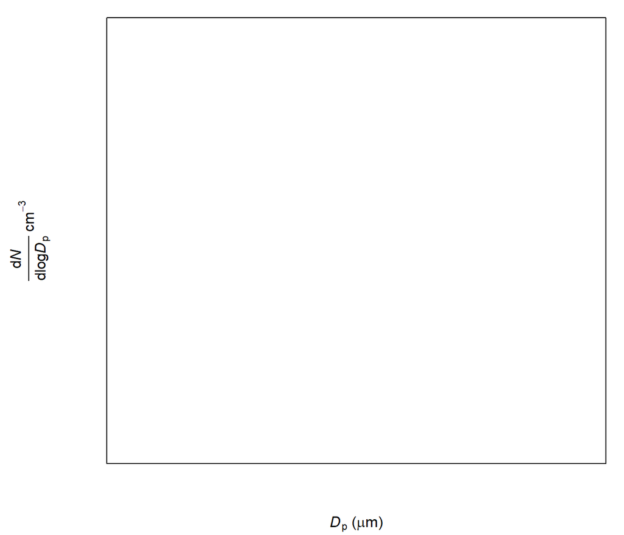

   Write the R code for inserting the axis labels into a graph.
3. How do you generate the following layout for `plot(co2)`?

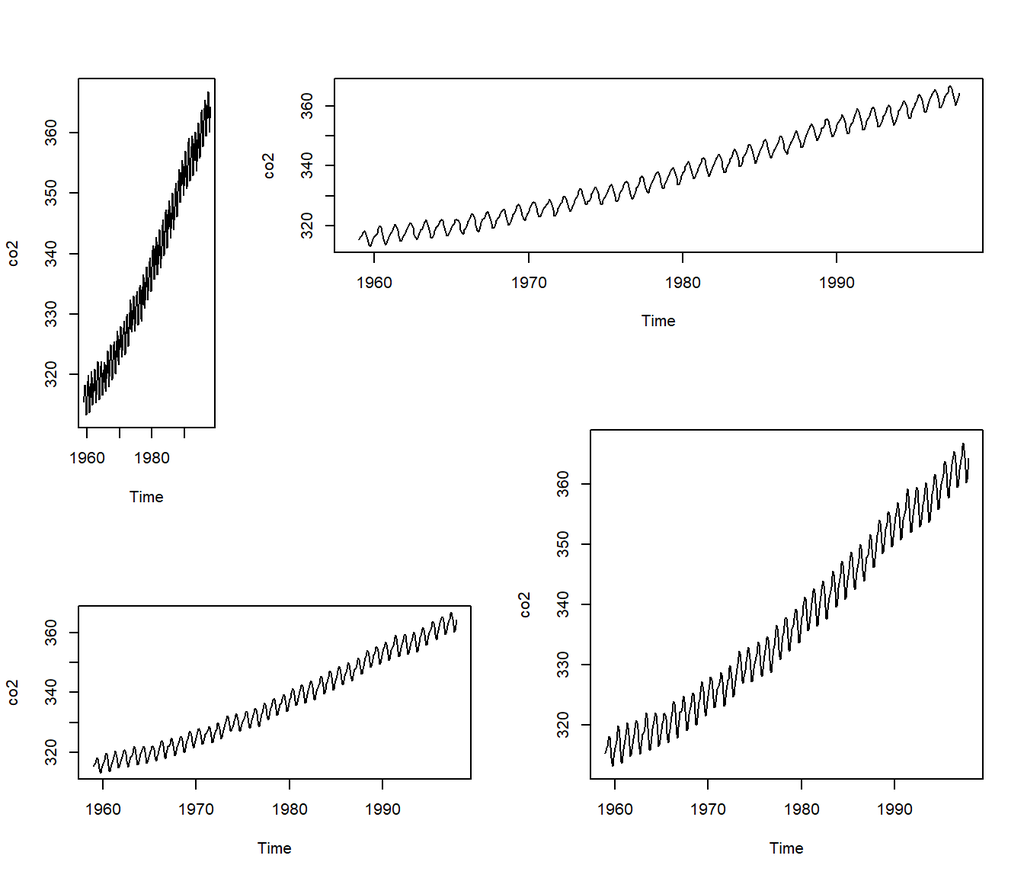

4. Insert the graph you create in Exercise 3 into a R Markdown document. Give proper numbering and a caption. Cross-refer it in the statement.